# Transmission analysis on MPG

Onur Akpolat

## Executive Summary

This report answers the following two questions for Motor Trend:

1. Is an automatic or manual transmission better for miles per gallon (MPG)?
2. Quantify the MPG difference between automatic and manual transmissions

## Data processing

```r
library(datasets)
data(mtcars)
str(mtcars)
```

Coerce the “cyl”, “vs”, “gear”, “carb” and “am” variables into factor variables.

```r
mtcars$cyl <- factor(mtcars$cyl)
mtcars$vs <- factor(mtcars$vs)
mtcars$gear <- factor(mtcars$gear)
mtcars$carb <- factor(mtcars$carb)
mtcars$am <- factor(mtcars$am,labels=c('Automatic','Manual'))
```

## Exploratory Analysis

Boxplotting (Appendix - Figure 1) the distribution of MPG of am, it shows that mandual transmission have a higher MPG than automatic transmissions. Exploring the relationships of the different variables in the dataset (Appendix - Figure 2), it shows that cyl, disp, hp, drat, wt, vs and am are correlated.

```r
cor(datasets::mtcars)["mpg",]
```

## Hypothesis Testing (Statistical Inference)

```r
aggregate(mpg~am, data = mtcars, mean)
```

[output not shown]

Manual transmissions mean is 7.24 MPGs higher that automatic transmissions. To determine significance a t-test is performed.

```r
autoData <- mtcars[mtcars$am == "Automatic",]
manualData <- mtcars[mtcars$am == "Manual",]
t.test(autoData$mpg, manualData$mpg)
```

[output not shown]

Null hypothesis is rejected as the p-value is 0.00137. There is signifiance difference in the mean MPG between automatic transmissions and manual transmissions.

## Regression Analysis

In this section a linear regression models based on the different variables are built.

### Model building and selection

Initially we include all variables of MPG. By performing a stepwise model selection we repeatedly select the most significant predictors and build the best model.

```r
initialModel <- lm(mpg ~ ., data = mtcars)
bestModel <- step(initialModel, direction = "both")
summary(bestModel)
```

[output not shown]

The adjusted R-squared value of 0.84 which means that 84% of the variability in the model is explained.

Next the base model will be compared with only am as the predictor variable wtih the best model.

```r
baseModel <- lm(mpg ~ am, data = mtcars)
anova(baseModel, bestModel)
```

[output not shown]

The p-value obtained is significant and we reject the null hypothesis.

## Residuals and Diagnostics

From the plots in Figure 3 (Appendix) there are following observations:

- Randomly scatterend points verify the indepedence condition.
- The Normal Q-Q plot indicates that the residuals are normally distributed.
- Scale-Locaton plot indicates constant variance.

Computation of some regression diagnostics will be performed to find out these leverage points.

```r
leverage <- hatvalues(bestModel)
tail(sort(leverage),3)
```

[output not shown]

```r
influential <- dfbetas(bestModel)
tail(sort(influential[,6]),3)
```

[output not shown]

The above results show that the anayslsi was correct, as the same cars appear in the residual plots.

## Results

Based on the observations from our best fit model, we can conclude the following,

- Manual transmission cards get more MPG compared to automatic transmissions.
- MPG will decrease by 2.5 for every 1000 lb increase in weight (wt).
- MPG decreases with increase of horse power (hp).

## Appendix

### Figure 1 - Boxplot | MPG by transmission type

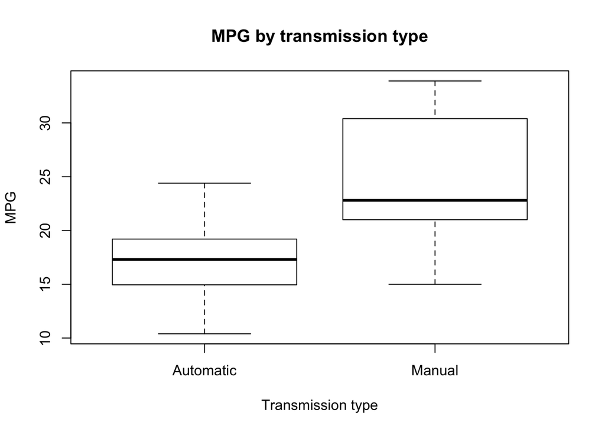

```r
plot(mpg ~ am, data = mtcars, main = "MPG by transmission type", xlab = "Transmission type", ylab = "MPG")
```

### Figure 2 - Pairs | MPG by transmission type

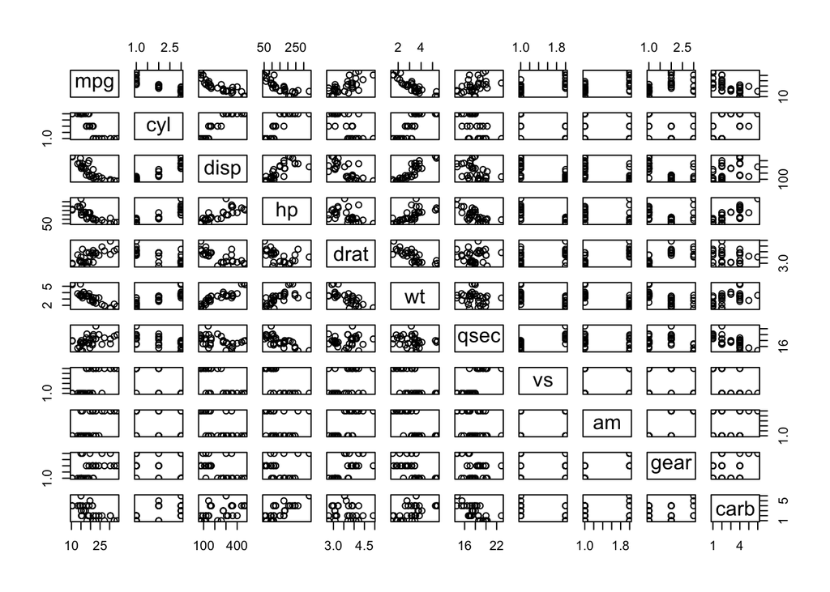

```r
pairs(mpg ~ ., data = mtcars)
```

### Figure 3 - Residuals & Diagnostics

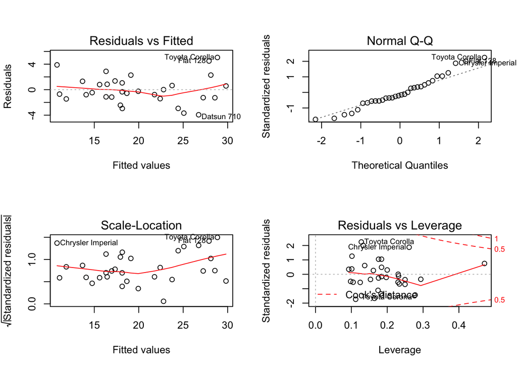

```r
par(mfrow=c(2, 2))
plot(bestModel)
```